# Heat, Pollution and Predators: Understanding Shark Attacks in a Complex Environment

Noel Demko, Manal Moubtassim, Jean Carlos Perez Perilla, Elias Zakarya

25/10/2023

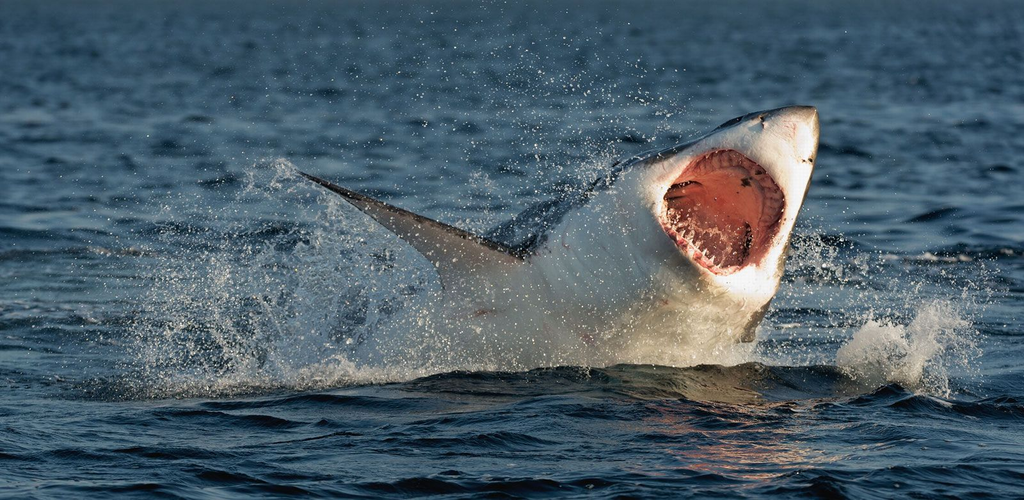

© USO—iStock/Getty Images

## **1. Introduction**

### 1.1 Background and motivation

At first, we wanted to analyse the impacts of the recent global pandemic on individuals within the context of a variety of mental health conditions, namely anxiety and depression, in a pre- and post-COVID framework. However, we decided to drop the idea due to a lack of data available regarding the topic, which wouldn’t have allowed us to conduct a thorough analysis. As we were searching for new topic ideas, we found a dataset that concerns shark attacks around the world. A group member has then told us about an incident that occurred during his last holidays in Egypt, involving a shark attack at a paradisiac beach. We discussed thereafter the presence of these predators in many different regions in the world including Florida, Hawaii, and Australia just to name a few. For this reason, we decided to dive deeper into the topic of shark attacks and explore potential influencing factors. After a few days of research and information gathering, we found that a wide range of factors are capable of influencing such incidents, both directly and indirectly. We all enjoy going on holidays and enjoy beaches while drinking a cocktail, and when we feel that temperature increases, we go in the water to refresh, but depending on the location we are, this could be unsafe.

Another motivation behind this project is our interest in the preservation of marine fauna. Very often human beings tend to primarily blame the animals for their fierce behavior (just look at the example of the attack that occurred in Hurghada during summer of 2023: after the death of the victim, the shark was killed!) but we often forget that the water it is their natural habitat, and that we are the guests. This point motivates us even more to study the phenomenon of attacks and to disclose how human activity causes shark attacks.

### 1.2 Poject Objectives

The project’s focus is to provide an understanding of the complex dynamics of shark attacks globally, by conducting an in-depth analysis on the different factors that influence the phenomenon. In addressing the topic at hand, we explore both direct and indirect influencing factors.

At the end of our work we want to learn how it is possible to reduce accidents caused by sharks. On the one hand, this is crucial to guarantee the safety of people who take pleasure in coastal waters and engage in water-related activities. On the other hand, the conservation of aquatic animals might benefit from this. Making efforts to preserve these species is essential for sustaining the health of marine ecosystems in a time when the extinction rate of many animal species is rising. Among the factors that might have an impact on the trend of shark attacks we have climatic variations. Ocean temperatures and currents are capable of affecting migration patterns and habitat preferences, which further complicates the dynamics of shark attacks. By providing a step-by-step analysis on climate-related aspects, we aim to provide empirical evidence on the impact of environmental changes on shark movements and interactions with humans.

This project’s goal is to contribute to the understanding of shark-related incidents and thereby to provide possible strategies such as policymaking, which would help mitigate such occurrences, ultimately safeguarding human life and protecting sharks. In essence, we aim to advance research on sustainable coexistence with the marine environment through actionable insights and intend to contribute to the broader efforts of marine conservation.

### 1.3 Related work

To have a global overview of the phenomenon, we also read some papers, here are some of them: - https://journals.plos.org/plosone/article?id=10.1371/journal.pone.0211049) - https://www.publish.csiro.au/mf/pdf/MF10181

What is more, while gathering information on Google Scholar, we found that this topic stirred up a considerable amount of discussion and analysis, and this was yet another compelling argument to investigate it further, by adding some points of discussion that have not been explored yet.

At this point we all agreed and decided to pursue this project.

### 1.4 Research Questions

1. What are the primary factors influencing the occurrence of shark attacks?
2. Is it true that shark attacks have been increasing with climate change?
3. What are the main factors leading to the fatality of a shark attack?

## **2. Data Sets**

### 2.1 Shark Attacks Data Set

Our first dataset contains the information in over 6000 shark attacks that have occurred worldwide over the course of the past centuries. The dataset was obtained from the Shark Research Institute’s (SRI) website, which carries out and funds rigorous, peer-reviewed shark field research and instructs people using scientific data.

Even though the dataset is owned by the SRI, we have downloaded it through the following plateform: https://www.kaggle.com/datasets/teajay/global-shark-attacks.

```r
# Create a 2x2 table. The first column represents the name of variables, the second one the description of each variable

Variables <- c("Case Number", "Date", "Year", "Type", "Country", "Area", "Location", "Activity", "Name", "Sex", "Age", "Injury", "Fatal", "Time", "Species", "Investigator.or.Source", "pdf", "href.formula", "Case Number 2")
Description <- c("Case Number of accident", "Date of the accident", "Year of accident", "Whether the victim provoked the shark or not", "Country of accident", "Region", "Location", "Activity the victim was doing before accident","Name of the victim", "Sex of the victim", "Age of the victim","Injury provoked by the accident", "Whether the accident led to death or not (Binary variable)", "Time of accident", "Shark Species", "Investigator of the accident", "Pdf information of the accident", "Pdf link of the accident", "Case number (same aas the first one)")


Table1 <- data.frame(Variable = Variables, Description = Description)

# The knitr::kable() allows to visualize the table
knitr::kable(Table1)
```

| Variable | Description |
| --- | --- |
| Case Number | Case Number of accident |
| Date | Date of the accident |
| Year | Year of accident |
| Type | Whether the victim provoked the shark or not |
| Country | Country of accident |
| Area | Region |
| Location | Location |
| Activity | Activity the victim was doing before accident |
| Name | Name of the victim |
| Sex | Sex of the victim |
| Age | Age of the victim |
| Injury | Injury provoked by the accident |
| Fatal | Whether the accident led to death or not (Binary variable) |
| Time | Time of accident |
| Species | Shark Species |
| Investigator.or.Source | Investigator of the accident |
| pdf | Pdf information of the accident |
| href.formula | Pdf link of the accident |
| Case Number 2 | Case number (same aas the first one) |

### 2.2 Temperatures Data Set

Our second dataset contains the average temperature change for each country (annually, monthly and seasonally) from 1961 to 2022. It contains 9,657 observations.

The dataset was taken from the website of the Food and Agriculture Organization of United Nations: https://www.fao.org/faostat/en/#data/ET

```r
# Create a 2x2 table. The first column represents the name of variables, the second one the description of each variable

Variables <- c("Area Code", "Area", "Months ", "Month code ", "Element Code ", "Element", "Unit", "Years")
Description <- c("Code for each country", "Country for which the data has been collected", "Month during which the data on temperature has been collected", "Code of each month ", "Binary variable (7271: Temperature change; 6078: Standard Deviation)", "What is the data measuring (either temperature change or standard deviation of data collection)", "Unit of measure of temperature ", "Year of observations" )


Table2 <- data.frame(Variable = Variables, Description = Description)

# The knitr::kable() allows to visualize the table
knitr::kable(Table2)
```

| Variable | Description |
| --- | --- |
| Area Code | Code for each country |
| Area | Country for which the data has been collected |
| Months | Month during which the data on temperature has been collected |
| Month code | Code of each month |
| Element Code | Binary variable (7271: Temperature change; 6078: Standard Deviation) |
| Element | What is the data measuring (either temperature change or standard deviation of data collection) |
| Unit | Unit of measure of temperature |
| Years | Year of observations |

### 2.3 Sea Level Data Set

Our third dataset contains information on the global increase of sea level from 1993 to 2021. The following acronims are important to be noted: GMLS:Global mean sea level GIA: Global Isostatic Adjustment, which is the ongoing movement of land once burdened by ice-age glaciers (National Ocean Service, n.d.)

The dataset was taken from the website of the NASA: https://climate.nasa.gov/vital-signs/sea-level/

```r
# Create a 2x2 table. The first column represents the name of variables, the second one the description of each variable

Variables <- c("Year", "TotalWeightedObservations ", "GMSL_noGIA ", "StdDevGMSL_noGIA ", "SmoothedGSML_noGIA ", "GMSL_GIA", "StdDevGMSL_GIA", "SmoothedGSML_GIA", "SmoothedGSML_GIA_sigremoved")
Description <- c("Year of the observation", "Total Weighted Observations of Sea Level", "Global mean sea level variation in millimeters, with respect to 20-year TOPEX/Jason collinear mean reference (without considering the GIA)", "Standard Deviation of global mean sea level variation estimate in millimeters (without considering the GIA)", "Smoothed (60-day Gaussian type filter) GMSL variation in millimeters (without considering the GIA)", "Global mean sea level variation in millimeters, with respect to 20-year TOPEX/Jason collinear mean reference (considering the GIA)", "Standard Deviation of global mean sea level variation estimate in millimeters (considering the GIA)", "Smoothed (60-day Gaussian type filter) GMSL variation in millimeters (considering the GIA)", "Smoothed (60-day Gaussian type filter) Global Mean Sea Level variation in millimeters (considering the GIA) ; annual and semi-annual signal removed ")


Table3 <- data.frame(Variable = Variables, Description = Description)

# The knitr::kable() allows to visualize the table
knitr::kable(Table3)
```

| Variable | Description |
| --- | --- |
| Year | Year of the observation |
| TotalWeightedObservations | Total Weighted Observations of Sea Level |
| GMSL_noGIA | Global mean sea level variation in millimeters, with respect to 20-year TOPEX/Jason collinear mean reference (without considering the GIA) |
| StdDevGMSL_noGIA | Standard Deviation of global mean sea level variation estimate in millimeters (without considering the GIA) |
| SmoothedGSML_noGIA | Smoothed (60-day Gaussian type filter) GMSL variation in millimeters (without considering the GIA) |
| GMSL_GIA | Global mean sea level variation in millimeters, with respect to 20-year TOPEX/Jason collinear mean reference (considering the GIA) |
| StdDevGMSL_GIA | Standard Deviation of global mean sea level variation estimate in millimeters (considering the GIA) |
| SmoothedGSML_GIA | Smoothed (60-day Gaussian type filter) GMSL variation in millimeters (considering the GIA) |
| SmoothedGSML_GIA_sigremoved | Smoothed (60-day Gaussian type filter) Global Mean Sea Level variation in millimeters (considering the GIA) ; annual and semi-annual signal removed |

### 2.4 Greenhouse Gas Emissions Data Set

Our fourth dataset relates to GHG emissions, one of the main concerns linked to global warming. The dataset contains 31.315 observations on annual GHG emissions per country and per continent, but we will focus on the first case only.

The dataset was taken from the website Our World in Data: https://ourworldindata.org/annual-co2-emissions

```r
# Create a 2x2 table. The first column represents the name of variables, the second one the description of each variable

Variables <- c("Entity", "Code", "Year", "Annual CO₂ emissions")
Description <- c("Country examinated", "ISO Code", "Year of the observation", "GHG emissions per year")


Table4 <- data.frame(Variable = Variables, Description = Description)

# The knitr::kable() allows to visualize the table
knitr::kable(Table4)
```

| Variable | Description |
| --- | --- |
| Entity | Country examinated |
| Code | ISO Code |
| Year | Year of the observation |
| Annual CO₂ emissions | GHG emissions per year |

## **3. Data Wrangling**

The first step of our work is data cleaning. While collecting data for a study, it might happen to have some variables with missing information, worthless data or spelling mistakes In order to run a regression, it is fundamental that each column within a data set has no missing values and that information is written following the same format. This procedure takes the name of data cleaning, and it will cover the whole subsection.

Please be aware that at the beginning of each subsection we only provide **general** instructions of our cleaning. Through the code, you will get additional in-depth explanations of each step we took.

```r
#We start by selecting the packages that we will need to run our functions
library(tidyverse)
library(knitr)
library(readxl)
library(dplyr)
library(tidyr)
library(stringr)
library(countrycode)
library(ggplot2)
```

### 3.1 Attacks Cleaning

The first dataset we will examine is the one pertaining to shark attacks. It was quite full of misspellings and missing values, which required a lot of time and a very dense code to be able to clean it.

For our work, we have decided to only study the phenomenon of shark attacks from 1970 forward. In fact, it is possible to observe in the raw dataset that, before to this date, observations had more erroneous information. This leads one to believe that, more likely than not, the information we needed is more accurate if we do not travel too far back in time.

```r
attacks <- read.csv("attacks1.csv")
attacks <- attacks[1:3406, ]

#We drop the columns that we do not need. The country is enough for our study, so we will not take into consideration the precise areas. The injury is not useful as well, indeed, the fatality column already gives us enough information. The other columns all contain information that are not useful for a research.

attacks <- attacks %>% select( -'Area', -'Location', -'Injury', -'href', -'href.formula', -'Investigator.or.Source', -'pdf', -'Name',
                              -'Case.Number.1', -'Case.Number.2', -'original.order', -'X', -'X.1')

#____________________________________________________________________________________
#FIRSTLY WE WORK ON THE COUNTRY COLUMN

#Firstly we put everything in CAPS in order to group countries (The problem was only Fiji which was written sometimes in capital letters and sometimes not. The rest was good). When we run a table, we can see that all countries are written in the same way, but we have 6 NA. We decided to investigate them. To do this, used the function "which" to spot where the NA are. We found out that we could get the country of 2 of them because, the column with the precise area war filled. For row 2957 area says "English Channel", meaning that the attack happened in the UK, while for row 3388 the area is "Carribean Sea". As a consequence, we will fill this spot with Jamaica, since it is central to Carribean and has average temperatures similar to sourrounding countries.

#After that, we have investigated the other 4 NA: they don't have anything in common, nor we found any information about those attacks on internet, so we just deleted the rows. Now countries are clean.

attacks$Country <- toupper(attacks$Country)
attacks$Country <- na_if(attacks$Country, "") #We turned blank spots to NA

rows_with_NA <- which(is.na(attacks$Country))


attacks$Country <- gsub("COLUMBIA", "COLOMBIA", attacks$Country, ignore.case = TRUE)
attacks[2957, "Country"] <- "UNITED KINGDOM"
attacks[3388, "Country"] <- "JAMAICA"
attacks$Country <- gsub("UNITED ARAB EMIRATES \\(UAE\\)", "UNITED ARAB EMIRATES", attacks$Country) #We took off the part "\\(UAE\\)" from the United Arab Emirates


attacks <- subset(attacks, !is.na(Country))


#____________________________________________________________________________________

#NOW WE WORK ON THE DATE

#For this column, we will drop both the year (which is already included in another column) and the day, which we consider useless therefore, we will only keep the month


attacks$Date <- gsub("\\bReported\\b", "", attacks$Date, ignore.case = TRUE) #Remove the word "reported" which appeared sometimes
attacks$Date <-  gsub("\\bEarly\\b", "", attacks$Date, ignore.case = TRUE)#Remove the word "Early" which appeared sometimes
attacks$Date <- gsub("[[:digit:][:punct:]]", "", attacks$Date) #remove all signs

words_to_keep <- c("Jan", "Feb", "Mar", "Apr","May", "Jun", "Jul", "Aug", "Sep", "Oct", "Nov", "Dec")


# Remove words not in the specific list of months (words_to_keep) for each row
attacks$Date <- sapply(attacks$Date, function(sentence) {
  gsub(paste0("\\b(?!", paste(words_to_keep, collapse = "|"), "\\b)\\w+\\s*"), "", sentence, perl = TRUE)
})

attacks$Date <- trimws(attacks$Date) #remove white spaces (" Feb" becomes "Feb")

#when we run the table, we see that there are still some problems, that we will correct by hand (Jul Jul, Jula etc.). We run the function "gsub"  to correct mistakes.

attacks$Date <- gsub("Jul Jul", "Jul", attacks$Date)
attacks$Date <- gsub("Jula", "Jul", attacks$Date)
attacks$Date <- gsub("Julb", "Jul", attacks$Date)
attacks$Date <- gsub("July", "Jul", attacks$Date)
attacks$Date <- gsub("June", "Jun", attacks$Date)
attacks$Date <- gsub("May  Nov", "Aug", attacks$Date)
attacks$Date <- gsub("November", "Nov", attacks$Date)

#Once the spelling mistakes are good, We replace all NA by blank spaces and investigate them. Some of them actually have their month on the column "Case Number". The others don't have anything in common.

rows_with_mistakes <- attacks[attacks$Date == "", ]
attacks$Date[is.na(attacks$Date)] <- ""

attacks[132, "Date"] <- "Jun"
attacks[720, "Date"] <- "Dec"
attacks[1293, "Date"] <- "Jan"
attacks[1968, "Date"] <- "Apr"
attacks[3049, "Date"] <- "Dec"

#Finally, we remove the few NA that remained because they had no information that would have helped us getting the information.

attacks$Date <- na_if(attacks$Date, "")
attacks <- subset(attacks, !is.na(Date))

#NOW WE WORK ON AGE COLUMN

#To clean the column of the age we took off all the letters, we computed by hand the mean age of all victims that had a range for their year and finally transformed all the ages expressed in months to years (Meaning that: age from 10 to 12 became 11, while 18 eights old became 1.5)

attacks$Age <- gsub("18 months", "1.5", attacks$Age)
attacks$Age <- gsub("28 & 26", "27", attacks$Age)
attacks$Age <- gsub("18 or 20", "19", attacks$Age)
attacks$Age <- gsub("12 or 13", "12.5", attacks$Age)
attacks$Age <- gsub("46 & 34", "40", attacks$Age)
attacks$Age <- gsub("28, 23 & 30", "27", attacks$Age)
attacks$Age <- gsub("36 & 26", "31", attacks$Age)
attacks$Age <- gsub("8 or 10", "9", attacks$Age)
attacks$Age <- gsub("30 or 36", "33", attacks$Age)
attacks$Age <- gsub("6½", "6.5", attacks$Age)
attacks$Age <- gsub("21 & ?", "21", attacks$Age)
attacks$Age <- gsub("33 or 37", "35", attacks$Age)
attacks$Age <- gsub("23 & 20", "21.5", attacks$Age)
attacks$Age <- gsub("7      &    31", "19", attacks$Age)
attacks$Age <- gsub("32 & 30", "31", attacks$Age)
attacks$Age <- gsub("16 to 18", "17", attacks$Age)
attacks$Age <- gsub("21 or 26", "23.5", attacks$Age)



attacks$Age <- gsub("[A-Za-z]", "", attacks$Age) #Delete all letters and signs
attacks$Age <- na_if(attacks$Age, "") #replace blank spots with NA
attacks$Age <- as.numeric(gsub("[^0-9.]", "", attacks$Age)) #put age as logic and not char
```

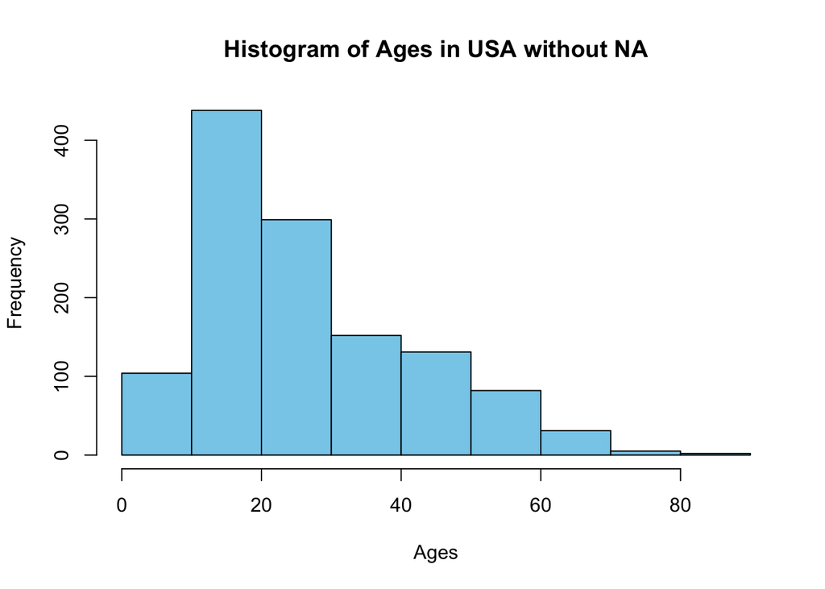

```r
#At this point, NA were still too much, so we will  work in the following way: for each country that presents LESS NA than the total observation, we compute an histogram (Age against frequency). If the distribution is normal, we substitute the NA with the mean. If it is left skewed, we substitute the NAs with the first quantile, if it is right skewed, we substitute it with the third quantile

#USA#

ages_in_USA <- attacks %>%
  filter(Country == "USA") %>%
  select(Age)

ages_vector <- ages_in_USA$Age

ages_without_na = na.omit(ages_vector)
ages_without_na <- as.numeric(ages_without_na)

hist(ages_without_na,
     col = "skyblue",
     xlab = "Ages",
     ylab = "Frequency",
     main = "Histogram of Ages in USA without NA"
) #We can see that the histogram is skewed, so we will replace the NAs by the first quartile of non-missing values
```

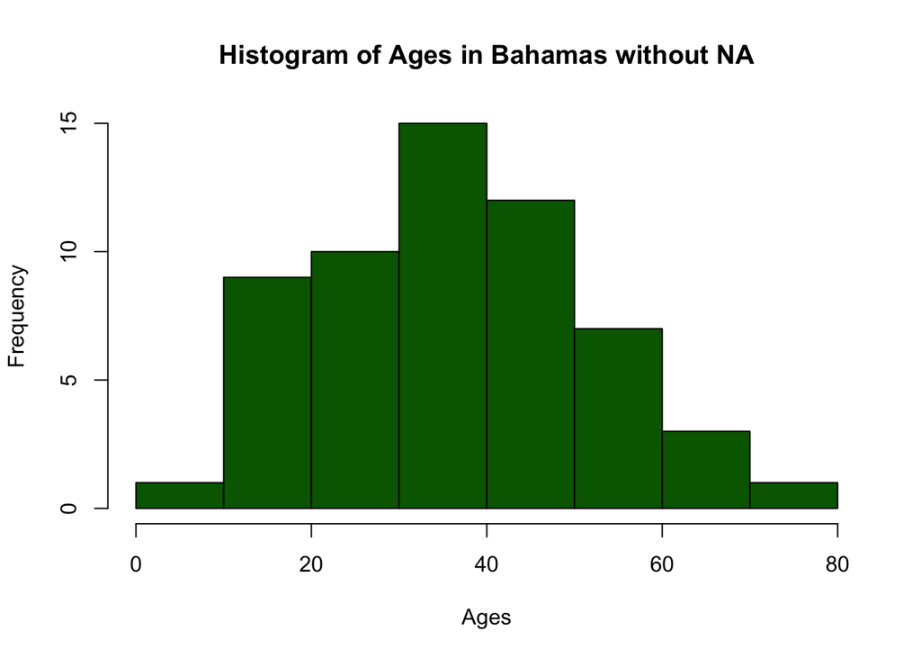

```r
q.25 <- quantile(ages_without_na, 0.25)
attacks$Age[attacks$Country == "USA" & is.na(attacks$Age)] <- q.25

#BAHAMAS#

ages_in_BAH <- attacks %>%
  filter(Country == "BAHAMAS") %>%
  select(Age)

ages_vector <- ages_in_BAH$Age

ages_without_na = na.omit(ages_vector)
ages_without_na <- as.numeric(ages_without_na)

hist(ages_without_na,
     col = "darkgreen",
     xlab = "Ages",
     ylab = "Frequency",
     main = "Histogram of Ages in Bahamas without NA"
)
```

```r
mean_BAH = mean(ages_without_na)

attacks$Age[attacks$Country == "BAHAMAS" & is.na(attacks$Age)] <- mean_BAH
```

```r
DT::datatable(attacks, options = list(pageLength = 10))
```

[output not shown]

[output cut: 2961 more lines]

### 3.2 Temperatures Cleaning

The main mission for this dataset was to change the entire structure of the dataset. Originally, the dataset had the years as columns (one column for each year), while the rows were represented by the different countries; the temperature observations were presented by month, quarter and year. Furthermore, for each country and each month/quarter/year, the dataset shows both the change in temperatures and the standard deviation.

To proceed with the cleaning, we eliminated the rows corresponding to the standard deviation (we will not work with it), and the monthly and quarterly observations: we are only interested in yearly temperature variations.

We then rotated the dataset so as to have all the years under a single column; we subsequently matched each country and year with its temperature change observation. Finally we added the ISO code to merge with the other datasets.

```r
temperature <- read_xlsx("Temperature.xlsx")

#R did not read the "°C" on the column Unit, so we changed it manually

temperature <- temperature %>% mutate(Unit = "°C")

#We take off all the columns that we do not need for our study

temperature <- temperature %>% select(-'Area Code (M49)', -'Months Code', -'Element Code')

#We wliminate all columns having an F at the end (For each year there are 2 columns (ex: 1961 - 1961F; 1962 - 1962F). The column with the F at the end of the Year is a column where only the letter E appears for each row. We tried to look for its meaning on the FAO website but we did not succeed. Therefore, we removed it. What is more, it is important to notice that it was in any case unimportant for our work).

columns_to_remove <- grep("F$", names(temperature), value = TRUE)
temperature <- temperature[, !(names(temperature) %in% columns_to_remove)]

# We keep only meteorological year, we don't need to work with monthly and seasonal data.

target_name <- "Meteorological year"
temperature <- temperature[temperature$Months == target_name, ]

target_name2 <- "Temperature change"
temperature <- temperature[temperature$Element == target_name2, ]



#  We take off the rest of the columns that we do not need

temperature <- temperature %>% select(-'Area Code', -'Months', -'Element', -'Unit')

#The column of each year starts with an Y (Y1961, Y1961...). We take it off, so that we can easily match data with other datasets.

new_colnames <- gsub("Y", "", colnames(temperature))
colnames(temperature) <- new_colnames
temperature <- na.omit(temperature)


# We transpose the dataset so that columns become rows. With this function we have a single column, where each row corresponds to a year, but countries became the columns now. We will work on this later in the code.
temperature <- t(temperature)

# I want the first row to be the header

colnames(temperature) <- temperature[1, ]
clean_temperature <- temperature[-1, ]

#col names in CAPS
colnames(clean_temperature) <- toupper(colnames(clean_temperature))


library(tidyr)

# Convert the matrix/array "clean_temperatures" to a data frame
temperature <- as.data.frame(clean_temperature)

# Add 'Year' as a separate column
temperature$Year <- rownames(clean_temperature)

# Reshape the data from wide to long format
temperature <- tidyr::pivot_longer(temperature,
                                     cols = -Year,
                                     names_to = "Country",
                                     values_to = "Temperature")

# Reorder columns as per your desired format
temperature <- temperature[c("Year", "Country", "Temperature")]

#As we said at the beginning, we only work with data from 1970
temperature <- temperature %>% filter(Year >= 1970)
temperature$Year <- as.numeric(temperature$Year)

temperature <- temperature %>%
  mutate(Country = ifelse(Country == "UNITED STATES OF AMERICA", "USA", Country))

#As for the attacks dataset, we add a column for the ISO code.

temperature$ISO_Code <- countrycode(temperature$Country, "country.name", "iso3c")
temperature$ISO_Code[temperature$Country %in% c("MICRONESIA") & is.na(temperature$ISO_Code)] <- "FSM"

#Now that we put ISO code, we can remove the country column
temperature <- temperature %>% select(-'Country')

DT::datatable(temperature, options = list(pageLength = 10))
```

|  | Year | Temperature | ISO_Code |
| --- | --- | --- | --- |
| 1 | 1970 | 0.813 | AFG |
| 2 | 1970 | -0.106 | ALB |
| 3 | 1970 | 0.116 | DZA |
| 4 | 1970 | 0.121 | AND |
| 5 | 1970 | 0.248 | AGO |
| 6 | 1970 | 0.082 | AIA |
| 7 | 1970 | -0.133 | ATA |
| 8 | 1970 | 0.438 | ARG |
| 9 | 1970 | -0.007 | AUS |
| 10 | 1970 | -0.550 | AUT |

[output cut: 10696 more lines]

### 3.3 Sea Level Cleaning

We choose a data set about the sea level change observed during the last years. We start analyzing the sea level changes since 1993 because we did not find any data of years before. In this data set we had few columns but we only kept 2 columns that were the more relevant for us: the year and the GMSL_GIA. This last column is the global mean of sea level including the glacial isostatic adjustement (GIA). We choose the column with GIA and not without because this show the response of solid Earth to the past changes in surface loading by ice and water such as the glaciation and deglaciation.

```r
sealevel <- read.csv("sealevel.csv")

# keep the 2 columns we are interested to analyze because the other are irrelevant for our project
sealevel <- subset(sealevel, select = c(Year, GMSL_GIA))

#Show the year only the first time by creating a new column called Year2
sealevel$Year2 <- ifelse(duplicated(sealevel$Year), NA, sealevel$Year)

# delete column Year due to the creation of column Year 2
sealevel <- subset(sealevel, select = -Year)

# delete NA because it does not bring anything to our analysis
sealevel <- na.omit(sealevel)

#Change name of column Year
column <- gsub("2","",colnames(sealevel))
colnames(sealevel) <- column

DT::datatable(sealevel, options = list(pageLength = 10))
```

|  | GMSL_GIA | Year |
| --- | --- | --- |
| 1 | -38.59 | 1993 |
| 38 | -33.08 | 1994 |
| 75 | -24.23 | 1995 |
| 112 | -29.84 | 1996 |
| 148 | -28.52 | 1997 |
| 185 | -23.25 | 1998 |
| 222 | -26.81 | 1999 |
| 259 | -17.98 | 2000 |
| 296 | -15.14 | 2001 |
| 333 | -13.55 | 2002 |

[output cut: 19 more lines]

### 3.4 Greenhouse Gas Emissions Cleaning

Finally, the GHG emissions dataset was the easiest to clean. Indeed, we already have a column for the ISO code, so we simply had to filter the years so that the observations began in 1970.

```r
co2 <- read.csv("CO2.csv")

# Change names of columns in order to have the same columns that in the other datasets
names(co2)[names(co2) == "Entity"] <- "Country"
names(co2)[names(co2) == "Annual.CO..emissions"] <- "Annual CO2 Emissions"
names(co2)[names(co2) == "Code"] <- "ISO_Code"



# keep the 3 columns we are interested to analyze
co2 <- subset(co2, select = c("ISO_Code", "Year", "Annual CO2 Emissions"))


# only keep information starting in 1970 because we want to look at the evolution of
# the last 50 years
co2<- co2[co2$Year >= 1970, ]

co2$ISO_Code <- na_if(co2$ISO_Code, "")

co2 <- subset(co2, !is.na(ISO_Code))

DT::datatable(co2, options = list(pageLength = 10))
```

|  | ISO_Code | Year | Annual CO2 Emissions |
| --- | --- | --- | --- |
| 22 | AFG | 1970 | 1670397 |
| 23 | AFG | 1971 | 1893554 |
| 24 | AFG | 1972 | 1530347 |
| 25 | AFG | 1973 | 1635454 |
| 26 | AFG | 1974 | 1913152 |
| 27 | AFG | 1975 | 2121383 |
| 28 | AFG | 1976 | 1980859 |
| 29 | AFG | 1977 | 2384175 |
| 30 | AFG | 1978 | 2153300 |
| 31 | AFG | 1979 | 2232754 |

[output cut: 11164 more lines]

## **4. EDA**

### 4.1 Evolution of shark attacks through the years

With the y-axis showing the frequency of shark attacks and the x-axis showing the passage of time, the graph below displays a striking pattern in shark attacks over time. The data exhibits a recognizable pattern that indicates a steady increase in the quantity of shark attacks within the designated period. This rising tendency begs critical concerns regarding what is causing such an increase and necessitates more research into ecological, environmental, and human-related elements that could be involved in this occurrence. The graph emphasizes the need of keeping an eye on and comprehending the dynamics of these episodes in addition to providing a visual depiction of the rise in shark attacks.

This trend is a key research topic: why are marine attacks increasing year after year? What could be the reasons? In fact, the reasons can be various, for example of an ecological, environmental nature or linked to human seaside activity. The graph highlights the need to keep an eye on and understand the dynamics of these episodes, which is exactly what we will do during our study.

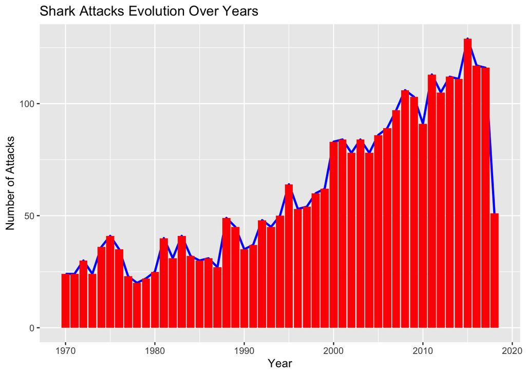

```r
ggplot(data = attacks, aes(x = Year)) +
  geom_smooth(stat = "count", aes(group = 1), color = "blue", size = 1) +
  geom_bar(stat = "count", fill = "red") +
  labs(title = "Shark Attacks Evolution Over Years", x = "Year", y = "Number of Attacks")
```

### 4.2 Pattern of shark attacks frequencies through the day

The bar graph below, where the x-axis indicates four time categories —morning, afternoon, evening, and night— displays the distribution of shark attacks throughout the day. The graph’s most noticeable aspect is how frequently shark attacks occur in the afternoon, followed by the morning, evening and night. This concentration of incidents in the afternoon raises intriguing questions about potential human behavioral factors that could contribute to this temporal pattern.

First and foremost, we believe that the afternoon is when most people choose to go swimming, which contributes to the frequency of shark attacks during this time. Recreational water activities such as swimming, surfing, kayaking, and other water sports are probably more popular during these times. Furthermore, the afternoon is when the seas are the warmest, so it’s intriguing to find out if this aspect also has a significant influence on shark activity. Conversely, the decreased number of assaults that occur at night may be related to less people using the water during that time, but there may be other possible reasons as well (less high temperatures, poorer visibility).

Lastly, we suppose that the medium frequencies of the morning and evening might correspond to transitional periods when shark and human behavior are changing.

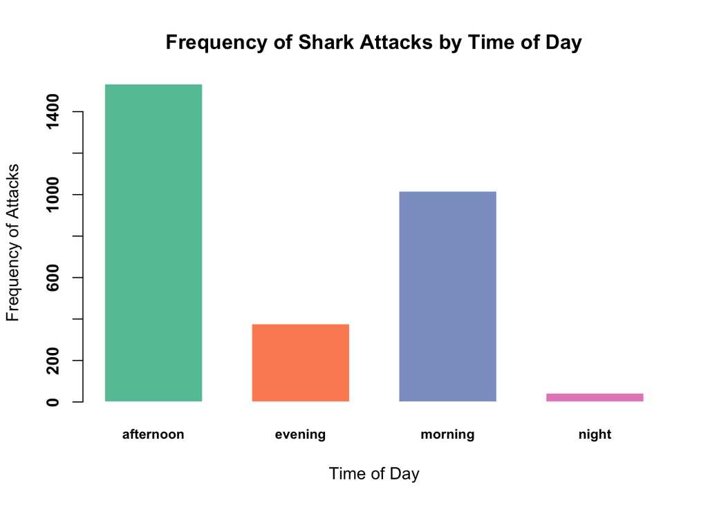

```r
bar_colors <- c("#66c2a5", "#fc8d62", "#8da0cb", "#e78ac3", "#a6d854")

barplot(table(attacks$Time),
        col = bar_colors,
        xlab = "Time of Day", ylab = "Frequency of Attacks",
        main = "Frequency of Shark Attacks by Time of Day",
        border = "white",  # White borders for bars
        ylim = c(0, max(table(attacks$Time)) + 5),  # Adjust y-axis limits
        space = 0.5,  # Adjust space between bars
        cex.names = 0.8,  # Adjust font size of axis labels
        font.axis = 2,  # Bold axis labels
        args.legend = list(title = "Time of Day", cex = 0.8),  # Legend settings
        beside = TRUE)
```

### 4.3 Fatality of shark attacks

**Are shark attacks more likely to lead to death?**

This pie shows that more than 85% of the attacks were not lethal. Only less than 13% of the total number of accidents were deadly, while for about 1% on these we have a lack of information. When we hear about shark attacks, we directly think about the degree of injury or death. This graph is a surprise for us because it shows us that shark do not kill that many people. Why? After some research, we learnt that sharks bite while they are exploring their environment. They bite humans, making them some injuries due to their mistaken identify. Moreover, when they meet surfers or swimmers, sharks bite them and then leave because the lack of blubber on humans. The low rate of shark attacks fatalities can tell us that sharks are not seeking for humans in order to feed themselves. Another factor that helps humans not to die is the rapid medical and emergency response that we can have at the beaches of high rate of sharks presence such as in the United States and Australia.

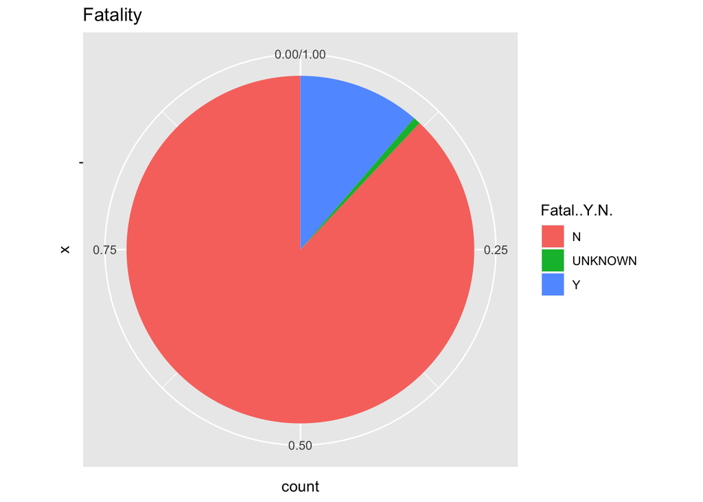

```r
ggplot(attacks, aes(x = "", fill = Fatal..Y.N.)) + geom_bar(position = "fill") + coord_polar("y") + labs(title = "Fatality")
```

**Fatalities by type of shark**

As we can see in this graph, most of attacks were not fatal, meaning that sharks injured a lot of people without taking their lives away. The types of sharks that did the most of accidents were the following ones: Bull shark, Tiger shark and White shark, with the deadlies being the last one. Why do they commit attacks? Probably because their feeding behavior. Maybe they misidentify their predators attacking people instead of animals like turtles, seals, or sea lions. This is consistent with Bull shark and Tiger shark being repetitevly named as the deadlies sharks in the seas and oeceans (CBS News, 2010). Another relevant information derived from this graph is the big number of unidentified sharks. Out of all the attacks recorded by our dataset, we have almost 600 Unidentified species. It is such a pity not to be able to have this information, which would have led us to more insightful results.

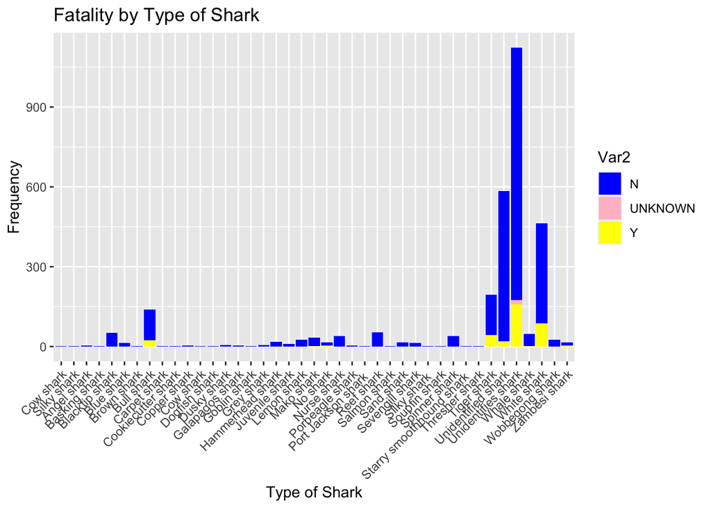

```r
summary_table <- table(attacks$Species, attacks$Fatal..Y.N.)

summary_df <- as.data.frame(summary_table)
ggplot(summary_df, aes(x = Var1, y = Freq, fill = Var2)) +
  geom_bar(stat = "identity") +
  labs(title = "Fatality by Type of Shark", x = "Type of Shark", y = "Frequency") +
  theme(axis.text.x = element_text(angle = 45, hjust = 1)) +
  scale_fill_manual(values = c("blue", "pink", "yellow"))
```

### 4.4 Evolution of temperatures through the yars

The graph below illustrates the change in global temperature throughout the last few decades, showing an overall increase in temperature over the 50-year period. Despite some fluctuations, the upward trend indicates a clear warming pattern, with a notable acceleration following the 1980s and one of the two most significant rises occurring in the recent decade.

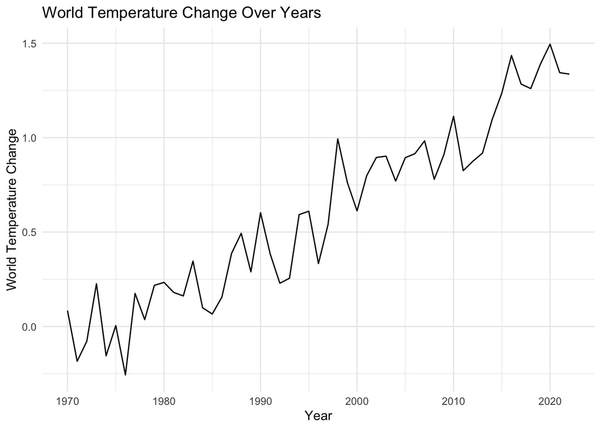

```r
# Filter out NA values and non-numeric values in the Temperature column
temperature_data_filtered <- temperature %>%
  filter(!is.na(Temperature), !is.na(as.numeric(Temperature)))

# Convert the Temperature column to numeric
temperature_data_filtered$Temperature <- as.numeric(temperature_data_filtered$Temperature)

# Calculate the mean temperature for each year
world_temperature <- temperature_data_filtered %>%
  group_by(Year) %>%
  summarise(World_Temperature = mean(Temperature, na.rm = TRUE))

# Create a line plot for the world temperature
ggplot(world_temperature, aes(x = Year, y = World_Temperature)) +
  geom_line() +
  labs(title = "World Temperature Change Over Years",
       x = "Year",
       y = "World Temperature Change") +
  theme_minimal()
```

### 4.5 Evolution of sea level through the yars

This line graph depicts the trend of rising sea levels from around the ’90s until the early 2020s, showing some fluctuations initially, and a notable upward trend thereafter. The early 2000s represent a steady rate of increase, with a minor decrease in the early 2010s. This pattern appears to be somewhat consistent with global temperature changes, and a steepening rise in the last couple of years indicate a complementary relation with the increasing temperature levels.

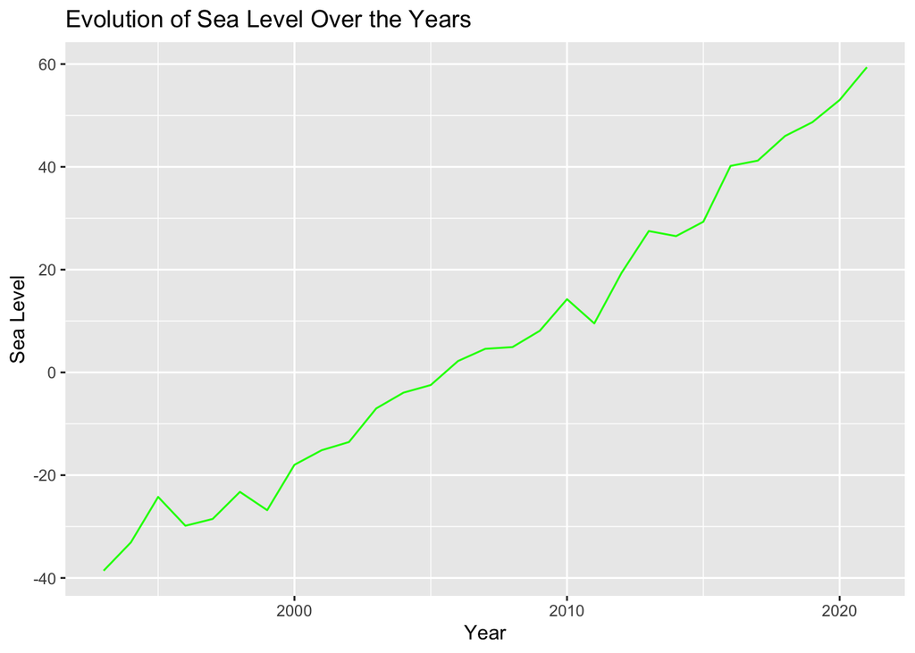

```r
# Create a line plot
ggplot(data = sealevel, aes(x = Year, y = GMSL_GIA)) +
  geom_line(color = "green") +
  labs(title = "Evolution of Sea Level Over the Years", x = "Year", y = "Sea Level")
```

### 4.6 CO2 emissions insights

**Trend of CO2 emissions per year**

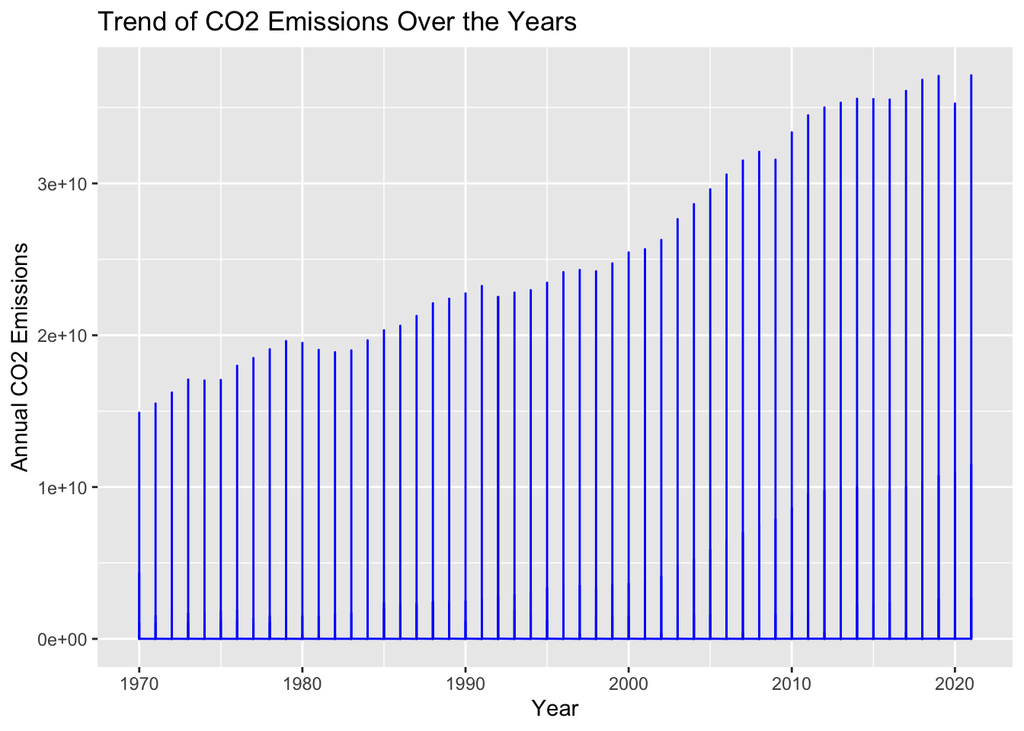

```r
# Create a line plot with backticks to show the trend in co2 emissions throughout the years
ggplot(data = co2, aes(x = Year, y = `Annual CO2 Emissions`)) +
  geom_line(color = "blue") +
  labs(title = "Trend of CO2 Emissions Over the Years", x = "Year", y = "Annual CO2 Emissions")
```

**Which continent generates more GHG emissions?**

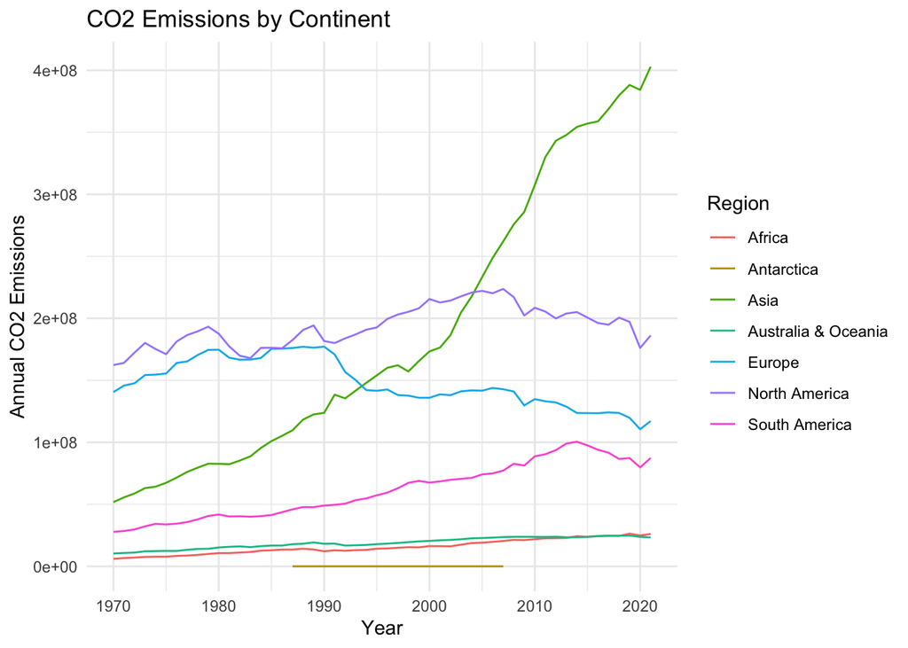

```r
# Step 2: Let's plot the Data
ggplot(mean_emissions, aes(x = Year, y = Mean_Emissions, color = Region)) +
  geom_line() +
  labs(title = "CO2 Emissions by Continent",
       x = "Year",
       y = "Annual CO2 Emissions") +
  theme_minimal()
```

## **8. References**

CBS News. (2010, October 24). Five Most Dangerous Sharks to Humans. https://www.cbsnews.com/pictures/five-most-dangerous-sharks-to-humans/

Midway, S. R., Wagner, T., & Burgess, G. H. (2019). Trends in global shark attacks. PLOS ONE, 14(2), e0211049. https://doi.org/10.1371/journal.pone.0211049

West, J. G. (2011). Changing patterns of shark attacks in Australian waters. Marine and Freshwater Research, 62(6), 744. https://doi.org/10.1071/mf10181

World’s biggest CO₂ emitters 2021 | Statista. (2023, September 12). Statista. https://www.statista.com/statistics/271748/the-largest-emitters-of-co2-in-the-world/